# Chapter

## 2.3 Drug-resistant TB

[**Red text should appear as links once content is posted on the web** ]

Globally, about one quarter of deaths due to antimicrobial resistance (AMR) are caused by rifampicin-resistant tuberculosis (RR-TB) *(1)*, which includes multidrug-resistant TB (MDR-TB). The latter is defined as resistance to rifampicin and isoniazid, both of which are essential components of the first-line treatment regimen for TB and the two most effective anti-TB drugs. Isoniazid is also the most commonly used drug for TB preventive treatment. People with MDR-TB or RR-TB (MDR/RR-TB) require treatment with second-line drugs. Those with resistance to isoniazid but without resistance to rifampicin require a modified fluoroquinolone-containing treatment regimen. Fluoroquinolones are also a key component of all-oral treatment regimens for RR-TB.

Since 1994, the World Health Organization (WHO) has systematically collected and analysed data on levels of resistance to anti-TB drugs from countries and territories ( Box. 2.3.1). On an annual basis, these data have been used to produce global, regional and country-specific estimates of the number of incident cases of MDR/RR-TB for the latest calendar year, the proportions of TB cases with various combinations of resistance to first-line and second-line drugs, and global estimates of the number of TB cases with resistance to fluoroquinolones. For selected countries, the data can be used to assess trends in the burden of MDR/RR-TB.

Further country-specific details about the proportions of new and previously treated TB cases that have MDR/RR-TB and estimates of the number of people who developed MDR/RR-TB in 2020 are available in the Global tuberculosis report app and online country profiles .

Box 2.3.1  
Sources of data to estimate levels of anti-TB drug resistance

The Global Project on Anti-TB Drug Resistance Surveillance, established and hosted by WHO since 1994, is the world’s oldest and largest global surveillance system for AMR *(4)*. Representative data on drug resistance are currently available for 184 countries and territories worldwide, which collectively account for more than 96% of the world’s population and incident cases of TB. With the expansion of rapid molecular tools, an increasing number of countries have transitioned from a reliance on periodic surveys to the establishment of continuous surveillance systems based on routine drug susceptibility testing (DST) of Mycobacterium tuberculosis isolates for at least rifampicin, and for at least 80% of patients with bacteriologically confirmed pulmonary TB. Of the 184 countries and territories with representative data in 2020, 137 have continuous surveillance systems and 47 rely on epidemiological surveys of bacterial isolates collected from representative samples of patients ( Fig. 2.3.5). The global coverage of drug-resistance surveillance data is shown in Fig. 2.3.6. A total of 39 of the 43 countries that are in one or both of the WHO lists of high TB burden and high MDR/RR-TB burden countries being used in the period 2021–2025 have data on levels of drug resistance. The number of data points on rifampicin resistance is shown for each country in Fig. 2.3.7. WHO published the sixth edition of *Guidance for the surveillance of drug resistance in tuberculosis* in 2021 *(5)*. The new edition provides the latest quality standards for surveillance of drug resistance in TB, aligned with important new developments in the field.

**References**

1. Review on antimicrobial resistance. Tackling drug-resistant infections globally: final report and recommendations. 2016 (https://amr-review.org/sites/default/files/160525_Final%20paper_with%20cover.pdf, accessed 13 August 2021).
2. Global tuberculosis report 2020. Geneva: World Health Organization; 2020 (https://www.who.int/publications/i/item/9789240013131, accessed 2 August 2021).
3. WHO consolidated guidelines on tuberculosis, Module 4: Treatment – drug-resistant tuberculosis treatment. Geneva: World Health Organization; 2020 (https://www.who.int/publications/i/item/9789240007048, accessed 13 August 2021).
4. Zignol M, Dean AS, Falzon D, et al. Twenty years of global surveillance of antituberculosis-drug resistance. N Eng J Med. 2016;375(11):1081–9 (https://www.nejm.org/doi/10.1056/NEJMsr1512438, accessed 16 August 2021).
5. Guidance for the surveillance of drug resistance in tuberculosis: Sixth edition. Geneva: World Health Organization; 2021 (https://www.who.int/publications/i/item/9789240018020, accessed 13 August 2021).

### Fig. 2.3.1 Percentage of new TB cases with MDR/RR-TB<sup>a</sup>

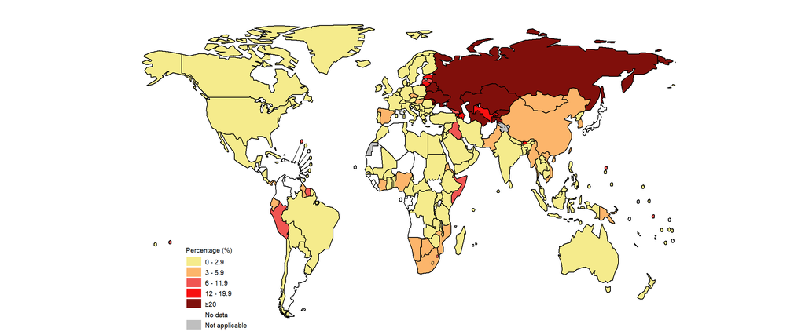

<sup>a</sup> Percentages are based on the most recent data point for countries with representative data from 2006 to 2021. Model-based estimates for countries without data are not shown. MDR-TB is a subset of RR-TB.

### Fig. 2.3.2 Percentage of previously treated TB cases with MDR/RR-TB<sup>a</sup>

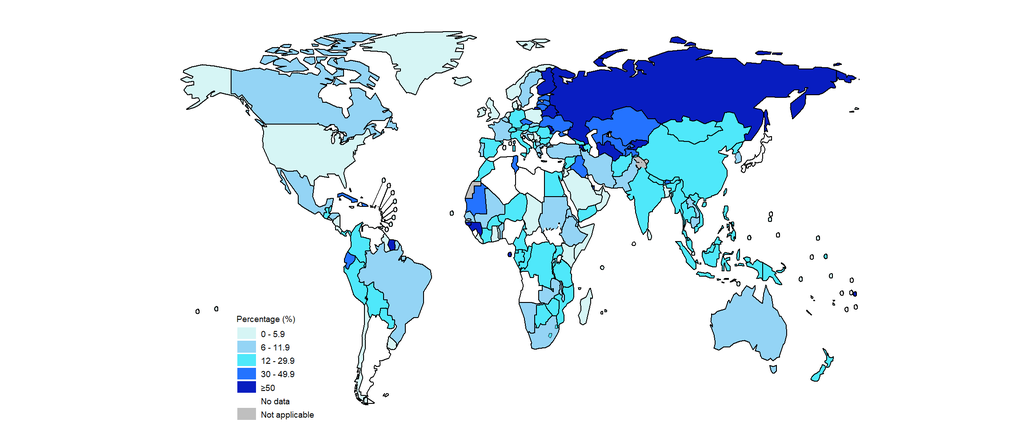

<sup>a</sup> Percentages are based on the most recent data point for countries with representative data from 2006 to 2021. Model-based estimates for countries without data are not shown. MDR-TB is a subset of RR-TB.

### Fig. 2.3.5 Source of data for rifampicin resistance among new cases, 1996–2021

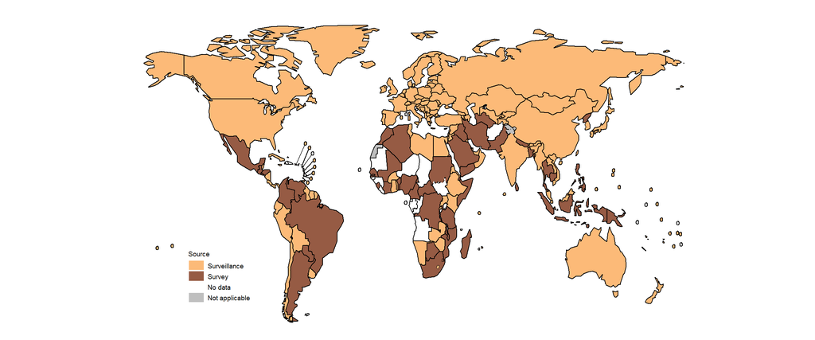

### Fig. 2.3.6 Most recent year of data on rifampicin resistance among new cases, 1996–2021<sup>a</sup>

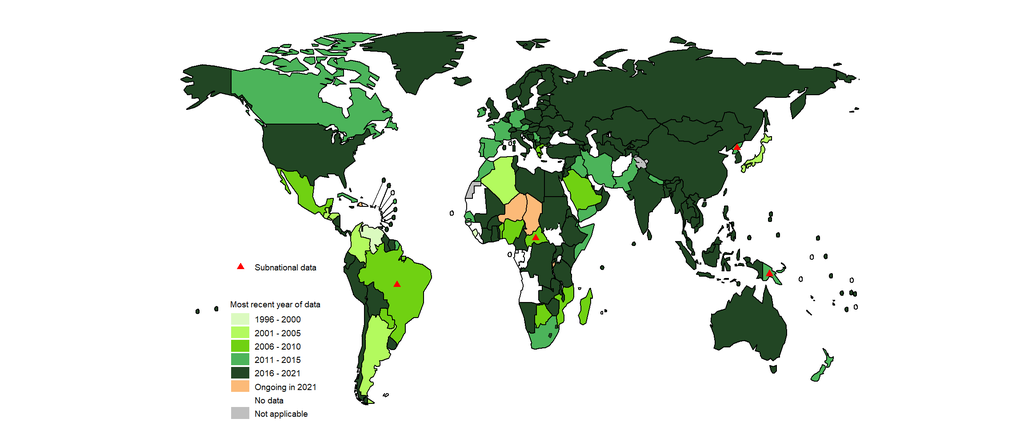

<sup>a</sup> Ongoing in 2021 refers to first-ever national surveys of anti-TB drug resistance that are being planned or implemented. For countries that are planning or implementing repeat surveys, the most recent year of data is shown.

### Fig. 2.3.7 Number of data points on rifampicin resistance among new cases, 1996–2021<sup>a</sup>

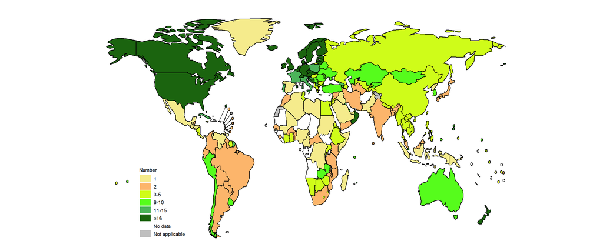

<sup>a</sup> In 2019–2021, first-ever national drug-resistance surveys were completed in Mali and Timor-Leste, and repeat surveys were completed in Bangladesh, Malawi, the Philippines and Zambia (provisional results).